# Reproducible Research / NOOA - Severe Weather Events

Myrba

26/9/2020

### **Assignment: Reproducible Research / Week 4 / Course Project 2**

#### **Introduction**

- Storms and other severe weather events can cause both public health and economic problems for communities and municipalities.
- Many severe events can result in fatalities, injuries, and property damage, and preventing such outcomes to the extent possible is a key concern.

#### **Synopsis**

- This project involves exploring the U.S. National Oceanic and Atmospheric Administration’s (NOAA) storm database.
- This database tracks characteristics of major storms and weather events in the United States, including when and where they occur, as well as estimates of any fatalities, injuries, and property damage.

#### **Main Objective**

- The main objective of this research is to explore the ** NOAA Storm Database ** and find answers with some logic that allow us to understand doubts or questions about ** severe weather events **.

### **Data Processing**

#### **Setting up the environment for R**

##### **Installing Libraries**

```r
library(R.utils)
library(rmarkdown)
library(knitr)
library(plyr)
library(dplyr)
library(ggplot2)
library(lattice)
library(data.table)
library(grid)
library(gridExtra)
```

##### **Setting up Local Time and Language**

```r
Sys.setlocale("LC_TIME", "English")
```

#### Loading and preprocessing the data

##### **Read the base bz2 file “stormData.csv.bz2” that contains the data**

```r
dataInput_file <- "stormData.csv.bz2"
if (!file.exists(dataInput_file)) {
  data_URL <- "https://d396qusza40orc.cloudfront.net/repdata%2Fdata%2FStormData.csv.bz2"
  download.file(data_URL, destfile = dataInput_file)

}
if(!file.exists("stormdata.csv"))
{
  bunzip2("stormData.csv.bz2","stormdata.csv",remove=F)
}
#stormData <- read.csv("stormdata.csv", header=TRUE,sep=",")
```

##### **Activating cache=TRUE for storing stormData with Results**

```r
stormData <- read.csv("stormdata.csv", header=TRUE,sep=",")

glimpse(stormData)
```

```
## Rows: 902,297
## Columns: 37
## $ STATE__    <dbl> 1, 1, 1, 1, 1, 1, 1, 1, 1, 1, 1, 1, 1, 1, 1, 1, 1, 1, 1,...
## $ BGN_DATE   <chr> "4/18/1950 0:00:00", "4/18/1950 0:00:00", "2/20/1951 0:0...
## $ BGN_TIME   <chr> "0130", "0145", "1600", "0900", "1500", "2000", "0100", ...
## $ TIME_ZONE  <chr> "CST", "CST", "CST", "CST", "CST", "CST", "CST", "CST", ...
## $ COUNTY     <dbl> 97, 3, 57, 89, 43, 77, 9, 123, 125, 57, 43, 9, 73, 49, 1...
## $ COUNTYNAME <chr> "MOBILE", "BALDWIN", "FAYETTE", "MADISON", "CULLMAN", "L...
## $ STATE      <chr> "AL", "AL", "AL", "AL", "AL", "AL", "AL", "AL", "AL", "A...
## $ EVTYPE     <chr> "TORNADO", "TORNADO", "TORNADO", "TORNADO", "TORNADO", "...
## $ BGN_RANGE  <dbl> 0, 0, 0, 0, 0, 0, 0, 0, 0, 0, 0, 0, 0, 0, 0, 0, 0, 0, 0,...
## $ BGN_AZI    <chr> "", "", "", "", "", "", "", "", "", "", "", "", "", "", ...
## $ BGN_LOCATI <chr> "", "", "", "", "", "", "", "", "", "", "", "", "", "", ...
## $ END_DATE   <chr> "", "", "", "", "", "", "", "", "", "", "", "", "", "", ...
## $ END_TIME   <chr> "", "", "", "", "", "", "", "", "", "", "", "", "", "", ...
```

[output cut: 24 more lines]

```r
head(stormData)
```

```
##   STATE__           BGN_DATE BGN_TIME TIME_ZONE COUNTY COUNTYNAME STATE  EVTYPE
## 1       1  4/18/1950 0:00:00     0130       CST     97     MOBILE    AL TORNADO
## 2       1  4/18/1950 0:00:00     0145       CST      3    BALDWIN    AL TORNADO
## 3       1  2/20/1951 0:00:00     1600       CST     57    FAYETTE    AL TORNADO
## 4       1   6/8/1951 0:00:00     0900       CST     89    MADISON    AL TORNADO
## 5       1 11/15/1951 0:00:00     1500       CST     43    CULLMAN    AL TORNADO
## 6       1 11/15/1951 0:00:00     2000       CST     77 LAUDERDALE    AL TORNADO
##   BGN_RANGE BGN_AZI BGN_LOCATI END_DATE END_TIME COUNTY_END COUNTYENDN
## 1         0                                               0         NA
## 2         0                                               0         NA
## 3         0                                               0         NA
## 4         0                                               0         NA
## 5         0                                               0         NA
## 6         0                                               0         NA
##   END_RANGE END_AZI END_LOCATI LENGTH WIDTH F MAG FATALITIES INJURIES PROPDMG
```

[output cut: 20 more lines]

```r
names(stormData)
```

```
##  [1] "STATE__"    "BGN_DATE"   "BGN_TIME"   "TIME_ZONE"  "COUNTY"
##  [6] "COUNTYNAME" "STATE"      "EVTYPE"     "BGN_RANGE"  "BGN_AZI"
## [11] "BGN_LOCATI" "END_DATE"   "END_TIME"   "COUNTY_END" "COUNTYENDN"
## [16] "END_RANGE"  "END_AZI"    "END_LOCATI" "LENGTH"     "WIDTH"
## [21] "F"          "MAG"        "FATALITIES" "INJURIES"   "PROPDMG"
## [26] "PROPDMGEXP" "CROPDMG"    "CROPDMGEXP" "WFO"        "STATEOFFIC"
## [31] "ZONENAMES"  "LATITUDE"   "LONGITUDE"  "LATITUDE_E" "LONGITUDE_"
## [36] "REMARKS"    "REFNUM"
```

### **Results**

#### **Question 1 :**

- Across the United States, which types of events (as indicated in the EVTYPE variable) are most harmful with respect to population health?

#### **Answer :**

- To answer this question, it is clear that the main focus is on discovering the variables FATALITIES and INJURIES.
- It is from these variables that the information to be analyzed and subsequently plotted will be constructed.

##### **Retrieving and Listing Top 10 EVTYPE “Injuries” Data Elements for this Analysis**

```r
# Reviewing events that cause the most Injuries by Weather Event.

## The Procedure is aggregate the top 10 Injuries by the event type and sort the output in descending order


total_injuries <- aggregate(INJURIES~EVTYPE, stormData, sum)
total_injuries <- arrange(total_injuries, desc(INJURIES))
total10_injuries <- total_injuries[1:10, ]
total10_injuries
```

```
##               EVTYPE INJURIES
## 1            TORNADO    91346
## 2          TSTM WIND     6957
## 3              FLOOD     6789
## 4     EXCESSIVE HEAT     6525
## 5          LIGHTNING     5230
## 6               HEAT     2100
## 7          ICE STORM     1975
## 8        FLASH FLOOD     1777
## 9  THUNDERSTORM WIND     1488
## 10              HAIL     1361
```

##### **Retrieving and Listing Top 10 EVTYPE “Fatalities” Data Elements for this Analysis**

```r
# Reviewing events that cause the most fatalities by Weather Event

## The Procedure is aggregate the top 10 fatalities by the event type and sort the output in descending order

total_fatalities <- aggregate(FATALITIES~EVTYPE,stormData, sum)
total_fatalities <- arrange(total_fatalities, desc(FATALITIES))
total10_fatalities <- total_fatalities[1:10, ]
total10_fatalities
```

```
##            EVTYPE FATALITIES
## 1         TORNADO       5633
## 2  EXCESSIVE HEAT       1903
## 3     FLASH FLOOD        978
## 4            HEAT        937
## 5       LIGHTNING        816
## 6       TSTM WIND        504
## 7           FLOOD        470
## 8     RIP CURRENT        368
## 9       HIGH WIND        248
## 10      AVALANCHE        224
```

##### **Plots of Fatalities and Injuries by Events**

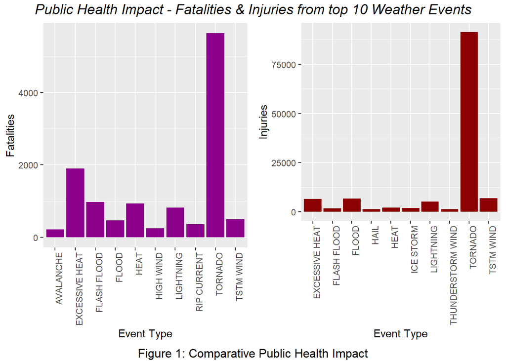

```r
#Show plot of fatalities by Event Type
fatalities_data <- ggplot(total10_fatalities, aes(x = EVTYPE, y = FATALITIES)) +
      geom_bar(stat = "identity", fill = "darkmagenta", width = NULL) +
      theme(axis.text.x = element_text(angle = 90, hjust = 1)) +
      xlab("Event Type") + ylab("Fatalities")
#plot(fatalities_data)

#Show plot of injuries by Event Type
injuries_data <- ggplot(total10_injuries, aes(x = EVTYPE, y = INJURIES)) +
      geom_bar(stat = "identity", fill = "darkred", width = NULL) +
      theme(axis.text.x = element_text(angle = 90, hjust = 1)) +
      xlab("Event Type") + ylab("Injuries")

#plot(injuries_data)

grid.arrange(fatalities_data, injuries_data, ncol=2, nrow=1, bottom = "Figure 1: Comparative Public Health Impact",
     top = textGrob("Public Health Impact - Fatalities & Injuries from top 10 Weather Events", gp=gpar(fontsize=14,font=3)))
```

- As can be seen in the previous figure, by far the event responsible for causing more damage in fatalities and injuries is the one corresponding to **Tornado**.

#### **Question 2 :**

- Across the United States, which types of events have the greatest economic consequences?

#### **Answer :**

- For this question, the analysis is based on the variables Crop (CROPDMG) and Property (PROPDMG) damage.
- These variables are precisely the ones that provide us with information on the damage regarding Crop and Property because of how it harms people, industries and therefore the United States.

##### **Data Explorations and Findings**

- After reviewing the column names, the property damage(PROPDMG) and crop damage(CROPDMG) columns both have another related column titled ‘exponents’ (i.e - PROPDMGEXP and CROPDMGEXP respectively).
- As a result, let’s convert the exponent columns into numeric data for the calculation of total property and crop damages encountered.

##### **Definitions and Computing**

- Property damage exponents for each level listed out & assigned those values for the property exponent data.
- Invalid data was excluded by assigning the value as ‘0’.
- Then, the property damage value was calculated by multiplying the property damage and property exponent value.

```r
unique(stormData$PROPDMGEXP)
```

```
##  [1] "K" "M" ""  "B" "m" "+" "0" "5" "6" "?" "4" "2" "3" "h" "7" "H" "-" "1" "8"
```

```r
# Assigning values for the property exponent stormData
stormData$PROPEXP[stormData$PROPDMGEXP == "K"] <- 1000
stormData$PROPEXP[stormData$PROPDMGEXP == "M"] <- 1e+06
stormData$PROPEXP[stormData$PROPDMGEXP == ""] <- 1
stormData$PROPEXP[stormData$PROPDMGEXP == "B"] <- 1e+09
stormData$PROPEXP[stormData$PROPDMGEXP == "m"] <- 1e+06
stormData$PROPEXP[stormData$PROPDMGEXP == "0"] <- 1
stormData$PROPEXP[stormData$PROPDMGEXP == "5"] <- 1e+05
stormData$PROPEXP[stormData$PROPDMGEXP == "6"] <- 1e+06
stormData$PROPEXP[stormData$PROPDMGEXP == "4"] <- 10000
stormData$PROPEXP[stormData$PROPDMGEXP == "2"] <- 100
stormData$PROPEXP[stormData$PROPDMGEXP == "3"] <- 1000
stormData$PROPEXP[stormData$PROPDMGEXP == "h"] <- 100
stormData$PROPEXP[stormData$PROPDMGEXP == "7"] <- 1e+07
stormData$PROPEXP[stormData$PROPDMGEXP == "H"] <- 100
stormData$PROPEXP[stormData$PROPDMGEXP == "1"] <- 10
stormData$PROPEXP[stormData$PROPDMGEXP == "8"] <- 1e+08

# Assigning '0' to invalid exponent stormData
stormData$PROPEXP[stormData$PROPDMGEXP == "+"] <- 0
stormData$PROPEXP[stormData$PROPDMGEXP == "-"] <- 0
stormData$PROPEXP[stormData$PROPDMGEXP == "?"] <- 0

# Calculating the property damage value
stormData$PROPDMGVAL <- stormData$PROPDMG * stormData$PROPEXP
```

```r
unique(stormData$CROPDMGEXP)
```

```
## [1] ""  "M" "K" "m" "B" "?" "0" "k" "2"
```

```r
# Assigning values for the crop exponent stormData
stormData$CROPEXP[stormData$CROPDMGEXP == "M"] <- 1e+06
stormData$CROPEXP[stormData$CROPDMGEXP == "K"] <- 1000
stormData$CROPEXP[stormData$CROPDMGEXP == "m"] <- 1e+06
stormData$CROPEXP[stormData$CROPDMGEXP == "B"] <- 1e+09
stormData$CROPEXP[stormData$CROPDMGEXP == "0"] <- 1
stormData$CROPEXP[stormData$CROPDMGEXP == "k"] <- 1000
stormData$CROPEXP[stormData$CROPDMGEXP == "2"] <- 100
stormData$CROPEXP[stormData$CROPDMGEXP == ""] <- 1

# Assigning '0' to invalid exponent stormData
stormData$CROPEXP[stormData$CROPDMGEXP == "?"] <- 0

# calculating the crop damage
stormData$CROPDMGVAL <- stormData$CROPDMG * stormData$CROPEXP
```

```r
# Property Damage Summary

# Procedure = aggregate the property damage by the event type and sort the output it in descending order

prop <- aggregate(PROPDMGVAL~EVTYPE,stormData, sum)
prop <- arrange(prop, desc(PROPDMGVAL))
prop <- prop[1:10, ]
prop
```

```
##               EVTYPE   PROPDMGVAL
## 1              FLOOD 144657709807
## 2  HURRICANE/TYPHOON  69305840000
## 3            TORNADO  56947380617
## 4        STORM SURGE  43323536000
## 5        FLASH FLOOD  16822673979
## 6               HAIL  15735267513
## 7          HURRICANE  11868319010
## 8     TROPICAL STORM   7703890550
## 9       WINTER STORM   6688497251
## 10         HIGH WIND   5270046260
```

```r
# Crop Damage Summary

# Procedure = aggregate the crop damage by the event type and sort the output it in descending order

crop <- aggregate(CROPDMGVAL~EVTYPE,stormData, sum)
crop <- arrange(crop, desc(CROPDMGVAL))
crop <- crop[1:10, ]
crop
```

```
##               EVTYPE  CROPDMGVAL
## 1            DROUGHT 13972566000
## 2              FLOOD  5661968450
## 3        RIVER FLOOD  5029459000
## 4          ICE STORM  5022113500
## 5               HAIL  3025954473
## 6          HURRICANE  2741910000
## 7  HURRICANE/TYPHOON  2607872800
## 8        FLASH FLOOD  1421317100
## 9       EXTREME COLD  1292973000
## 10      FROST/FREEZE  1094086000
```

##### **Plots of Damages**

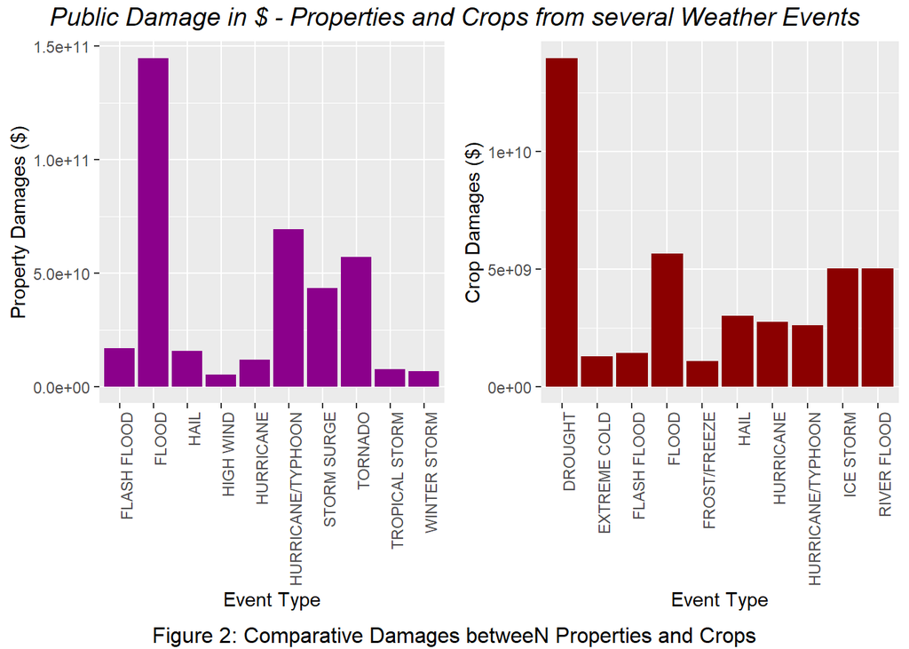

```r
#Show plot of Property Damages by Event Type
prop_data <- ggplot(prop, aes(x = EVTYPE, y = PROPDMGVAL)) +
      geom_bar(stat = "identity", fill = "darkmagenta", width = NULL) +
      theme(axis.text.x = element_text(angle = 90, hjust = 1)) +
      xlab("Event Type") + ylab("Property Damages ($)")
#plot(fatalities_data)

#Show plot of Crop Damages by Event Type
crop_data <- ggplot(crop, aes(x = EVTYPE, y = CROPDMGVAL)) +
      geom_bar(stat = "identity", fill = "darkred", width = NULL) +
      theme(axis.text.x = element_text(angle = 90, hjust = 1)) +
      xlab("Event Type") + ylab("Crop Damages ($)")

#plot(injuries_data)

grid.arrange(prop_data, crop_data, ncol=2, nrow=1, bottom = "Figure 2: Comparative Damages betweeN Properties and Crops",
     top = textGrob("Public Damage in $ - Properties and Crops from several Weather Events", gp=gpar(fontsize=14,font=3)))
```